# **IE - 579 HOMEWORK1**

- Task 1 – Curse of dimensionality and effect of sample size
- Task 2 – Practicing data manipulation skills on images

**TASK - 1**

**Number Of Dimension - Euclidean Distance From Orijin**

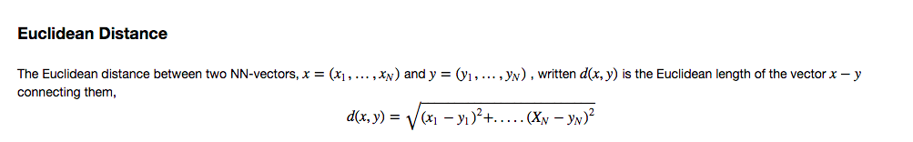

```python
from scipy.spatial.distance import cdist
import scipy
import numpy as np
import pandas as pd
import matplotlib.pyplot as plt
%matplotlib inline
plt.rcParams['figure.figsize'] = [12,10]
plt.style.use('seaborn-darkgrid')
```

```python
N_MAX = 15
M = int(1e+5)
dims = np.zeros(N_MAX, dtype=np.int32)
volume = np.zeros(N_MAX)
for N in range(1,N_MAX+1):
    y = np.random.uniform(low=-1, high=1,size=(M,N))
    # cdist computes distance between 2  matrices y-> (M,N) and [[0..0]]
    dist = cdist(y,np.expand_dims(np.zeros(N),0),metric='euclidean')
    p = np.sum(dist < 1)/M
    dims[N-1] = N
    volume[N-1] = p
df=pd.DataFrame(data={'dims': dims,'volume': volume})
print(df)
```

```
    dims   volume
0      1  1.00000
1      2  0.78562
2      3  0.52450
3      4  0.30813
4      5  0.16577
5      6  0.08044
6      7  0.03593
7      8  0.01603
8      9  0.00651
9     10  0.00283
10    11  0.00091
11    12  0.00035
12    13  0.00011
13    14  0.00004
14    15  0.00001
```

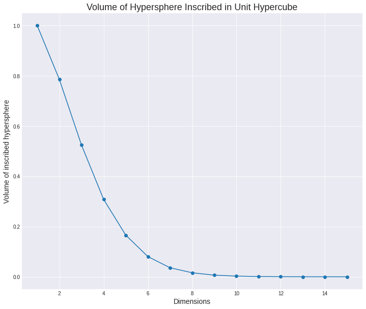

```python
plt.plot(df.dims, df.volume,'o-')
plt.title('Volume of Hypersphere Inscribed in Unit Hypercube',size=18)
plt.xlabel('Dimensions',size=14)
plt.ylabel('Volume of inscribed hypersphere',size=14)
```

# **Estimating the value of Pi using Monte Carlo**

**Monte Carlo methods** (or Monte Carlo experiments) are a broad class of computational algorithms that rely on repeated random sampling to obtain numerical results. Their essential idea is using randomness to solve problems that might be deterministic in principle. On the other hand we can say that Monte Carlo is a method that uses random sampling to predict the outcome (output) of an experiment.

To calculate the pi number with this method:

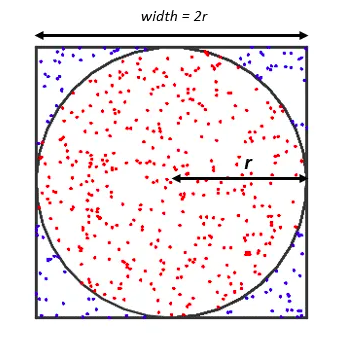

```python
N = 1000  # trials
X = np.random.uniform(-1, 1, N)
Y = np.random.uniform(-1, 1, N)
# Get radius of all points
rad_arr = np.sqrt((X ** 2) + (Y ** 2))
# Get boolean mask of points in circle
in_circle = rad_arr < 1.0
pi_est = 4 * np.sum(in_circle) / N
print(pi_est)
```

```
3.128
```

```python
N = 5000  # trials
X = np.random.uniform(-1, 1, N)
Y = np.random.uniform(-1, 1, N)
# Get radius of all points
rad_arr = np.sqrt((X ** 2) + (Y ** 2))
# Get boolean mask of points in circle
in_circle = rad_arr < 1.0
pi_est = 4 * np.sum(in_circle) / N
print(pi_est)
```

```
3.1344
```

```python
N = 10000  # trials
X = np.random.uniform(-1, 1, N)
Y = np.random.uniform(-1, 1, N)
# Get radius of all points
rad_arr = np.sqrt((X ** 2) + (Y ** 2))
# Get boolean mask of points in circle
in_circle = rad_arr < 1.0
pi_est = 4 * np.sum(in_circle) / N
print(pi_est)
```

```
3.1244
```

```python
N = 25000  # trials
X = np.random.uniform(-1, 1, N)
Y = np.random.uniform(-1, 1, N)
# Get radius of all points
rad_arr = np.sqrt((X ** 2) + (Y ** 2))
# Get boolean mask of points in circle
in_circle = rad_arr < 1.0
pi_est = 4 * np.sum(in_circle) / N
print(pi_est)
```

```
3.14832
```

```python
N = 50000  # trials
X = np.random.uniform(-1, 1, N)
Y = np.random.uniform(-1, 1, N)
# Get radius of all points
rad_arr = np.sqrt((X ** 2) + (Y ** 2))
# Get boolean mask of points in circle
in_circle = rad_arr < 1.0
pi_est = 4 * np.sum(in_circle) / N
print(pi_est)
```

```
3.15008
```

```python
N = 100000  # trials
X = np.random.uniform(-1, 1, N)
Y = np.random.uniform(-1, 1, N)
# Get radius of all points
rad_arr = np.sqrt((X ** 2) + (Y ** 2))
# Get boolean mask of points in circle
in_circle = rad_arr < 1.0
pi_est = 4 * np.sum(in_circle) / N
print(pi_est)
```

```
3.1492
```

```python
N = 1000000  # trials
X = np.random.uniform(-1, 1, N)
Y = np.random.uniform(-1, 1, N)
# Get radius of all points
rad_arr = np.sqrt((X ** 2) + (Y ** 2))
# Get boolean mask of points in circle
in_circle = rad_arr < 1.0
pi_est = 4 * np.sum(in_circle) / N
print(pi_est)
```

```
3.143784
```

we can only repeat the experiment for a large number of times. Hence, exact value of π can't be calculated. We can only get an estimate! More iterations = More accuracy

```python
import math
import random
```

```python
def run_experiment(n=10000):
    points = [(random.uniform(-1,1), random.uniform(-1,1)) for _ in range(n)]
    points_inside_circle = [(x,y)  for (x,y) in points if x**2 + y**2 <= 1]
    return 4 * len(points_inside_circle) / len(points)
```

```python
results = []
avg_pi_values = []
```

```python
for _ in range(10000):
    results.append(run_experiment())
    avg_pi = sum(results) / len(results)
    avg_pi_values.append(avg_pi)
```

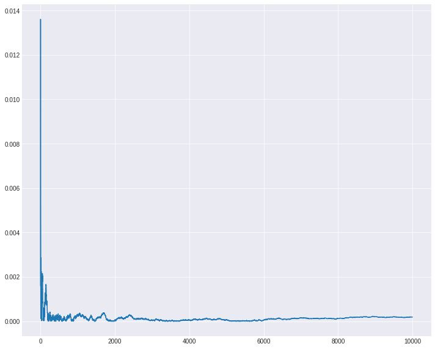

```python
avg_pi_errors = [abs(math.pi - pi) for pi in avg_pi_values]

plt.plot(avg_pi_errors)
```

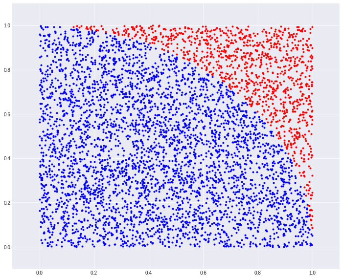

```
3.1368
```

```
(None, 'result')
```

```python
from pylab import plot,show,axis
from numpy import random,sqrt,pi

# scattering n points over the unit square
n = 5000
p = random.rand(n,2)

# counting the points inside the unit circle
idx = sqrt(p[:,0]**2+p[:,1]**2) < 1

plot(p[idx,0],p[idx,1],'b.') # point inside
plot(p[idx==False,0],p[idx==False,1],'r.') # point outside
axis([-0.1,1.1,-0.1,1.1])
show()

# estimation of pi
print(sum(idx).astype('double')/n*4),'result'
```

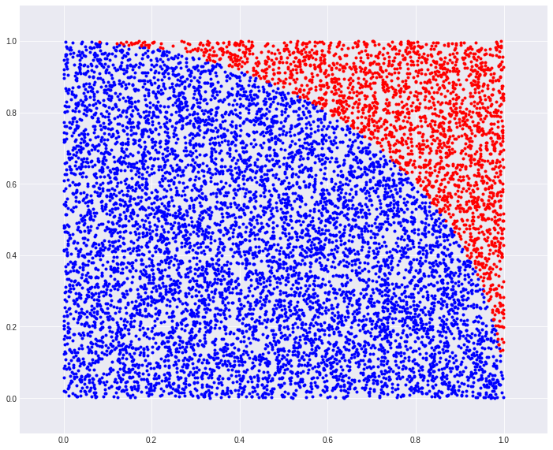

```
3.1288
```

```
(None, 'result')
```

```python
from pylab import plot,show,axis
from numpy import random,sqrt,pi

# scattering n points over the unit square
n = 10000
p = random.rand(n,2)

# counting the points inside the unit circle
idx = sqrt(p[:,0]**2+p[:,1]**2) < 1

plot(p[idx,0],p[idx,1],'b.') # point inside
plot(p[idx==False,0],p[idx==False,1],'r.') # point outside
axis([-0.1,1.1,-0.1,1.1])
show()

# estimation of pi
print(sum(idx).astype('double')/n*4),'result'
```

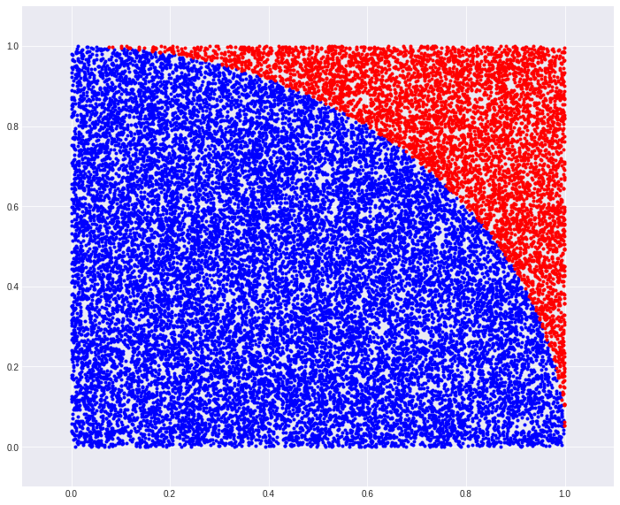

```
3.13472
```

```
(None, 'result')
```

```python
from pylab import plot,show,axis
from numpy import random,sqrt,pi

# scattering n points over the unit square
n = 25000
p = random.rand(n,2)

# counting the points inside the unit circle
idx = sqrt(p[:,0]**2+p[:,1]**2) < 1

plot(p[idx,0],p[idx,1],'b.') # point inside
plot(p[idx==False,0],p[idx==False,1],'r.') # point outside
axis([-0.1,1.1,-0.1,1.1])
show()

# estimation of pi
print(sum(idx).astype('double')/n*4),'result'
```

# If we ramp up the size of the Iterations from 5000 to 1 Million, the estimate of π gets a bit closer

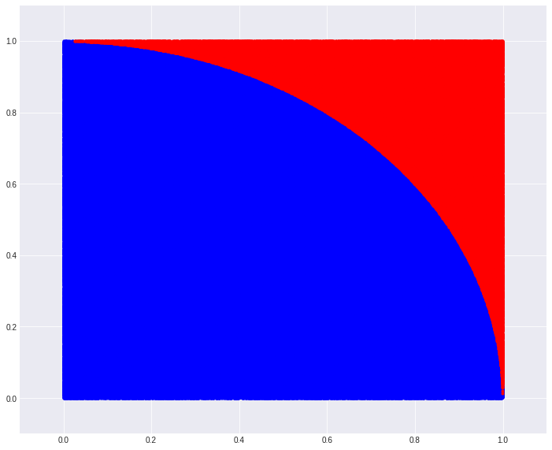

```
3.143444
```

```
(None, 'result')
```

```python
from pylab import plot,show,axis
from numpy import random,sqrt,pi

# scattering n points over the unit square
n = 1000000
p = random.rand(n,2)

# counting the points inside the unit circle
idx = sqrt(p[:,0]**2+p[:,1]**2) < 1

plot(p[idx,0],p[idx,1],'b.') # point inside
plot(p[idx==False,0],p[idx==False,1],'r.') # point outside
axis([-0.1,1.1,-0.1,1.1])
show()

# estimation of pi
print(sum(idx).astype('double')/n*4),'result'
```

```python
d = 1 # The number of dimensions
n = int(1e5) # The number of Monte Carlo trials
Zn = 0
for i in range(n):
    x1 = np.random.uniform(-1,1,1000)
    R = np.sqrt(x1**2) # Calculate distance from the orgin
    if R.any() <= 1: # Check for a hit
        Zn += 1 # If there's a hit increment Zn
V1D = 2**d*Zn/n # The Monte Carlo calculation of the sphere volume
V1Dexact = 2 # The known value of the volume of the sphere
ratio = V1D/V1Dexact # Compare the calculated volume to the known volume
print('The volume of a', d, 'D sphere from the Monte Carlo simulation is', V1D)
print('The exact volume is', V1Dexact, 'and the ratio of the two is', V1D/V1Dexact)
```

```
The volume of a 1 D sphere from the Monte Carlo simulation is 2.0
The exact volume is 2 and the ratio of the two is 1.0
```

```python
d = 2 # The number of dimensions
n = int(1e5) # The number of Monte Carlo trials
Zn = 0
for i in range(n):
    x1 = np.random.uniform(-1,1,1000)
    x2 = np.random.uniform(-1,1,1000)
    R = np.sqrt(x1**2 + x2**2) # Calculate distance from the orgin
    if R.any()<= 1: # Check for a hit
        Zn += 1 # If there's a hit increment Zn
V2D = 2**d*Zn/n # The Monte Carlo calculation of the sphere volume
V2Dexact = np.pi; # The known value of the volume of the sphere
ratio = V2D/V2Dexact # Compare the calculated volume to the known volume
print('The volume of a', d, 'D sphere from the Monte Carlo simulation is', V2D)
print('The exact volume is', V2Dexact, 'and the ratio of the two is', V2D/V2Dexact)
```

```
The volume of a 2 D sphere from the Monte Carlo simulation is 4.0
The exact volume is 3.141592653589793 and the ratio of the two is 1.2732395447351628
```

```
D=2	N=10000000	N_in=7853615		pi_est=3.14277	V=3.14145
D=3	N=10000000	N_in=5235725		pi_est=3.14168	V=4.18858
D=4	N=10000000	N_in=3083280		pi_est=3.14151	V=4.93325
D=5	N=10000000	N_in=1645981		pi_est=3.14184	V=5.26714
D=6	N=10000000	N_in=806566		pi_est=3.14144	V=5.16202
D=7	N=10000000	N_in=368688		pi_est=3.14112	V=4.71921
D=8	N=10000000	N_in=157924		pi_est=3.14205	V=4.04285
D=9	N=10000000	N_in=064701		pi_est=3.14143	V=3.31269
D=10	N=10000000	N_in=024830		pi_est=3.14088	V=2.54259
D=11	N=10000000	N_in=009167		pi_est=3.14120	V=1.87740
D=12	N=10000000	N_in=003342		pi_est=3.14181	V=1.36888
D=13	N=10000000	N_in=001135		pi_est=3.14127	V=0.92979
D=14	N=10000000	N_in=000387		pi_est=3.14189	V=0.63406
D=15	N=10000000	N_in=000100		pi_est=3.14215	V=0.32768
```

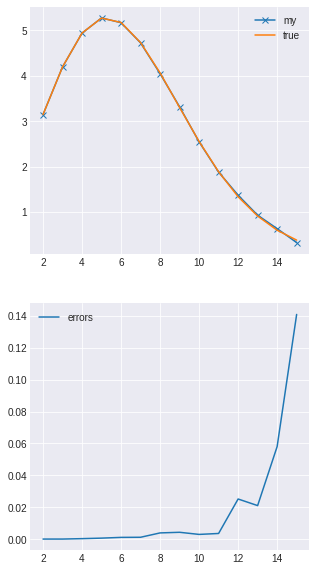

```python
from __future__ import print_function, division
import numpy as np
import scipy.special
import pylab as plt
import time

Dmax = 15 # Largest dimension
N = int(1e7) # Monte Carlo samples 10ˆ7

data = []

for D in np.arange(2,Dmax+1): # Loop
    t0=time.time()
    # Generate points in cube
    all = np.random.uniform(-1,1, D*N).reshape(N,D)

    # Distance from cube center
    distance = np.sum(all**2,axis=1)**0.5

    # Number of points within sphere
    Ninside = np.sum(distance<=1)

    # Fraction of points within sphere
    fractioninside = Ninside/N

    # Volume of the cube (from -1 to 1)
    cube = 2**D

    # Volume of the sphere
    sphere = fractioninside * cube

    X = np.random.uniform(-1, 1, N)
    Y = np.random.uniform(-1, 1, N)
    # Get radius of all points
    rad_arr = np.sqrt((X ** 2) + (Y ** 2))
    # Get boolean mask of points in circle
    in_circle = rad_arr < 1.0
    pi_est = 4 * np.sum(in_circle) / N

    solution = np.pi**(D/2) / scipy.special.gamma( D/2 + 1) # True value
    diff= np.abs(sphere-solution)/solution # Error

    print("D=%i\tN=%i\tN_in=%06d\t\tpi_est=%.5f\tV=%.5f" %(D,N,Ninside,pi_est,sphere))

    data.append([D,sphere,solution,diff]) # Store data


# Plots...
dims, my,true,errors = np.array(data).T
fig, axs= plt.subplots(2, 1,figsize=(5,10))
axs[0].plot(dims,my,label='my',ls='-',marker='x')
axs[0].plot(dims,true,label='true',ls='-')
axs[1].plot(dims,errors,label='errors')
[ax.legend() for ax in axs]
plt.show()
```

For D=2 we get 3.14… which is 𝜋. The volume then goes up till D=5. That’s the number of dimensions in which a sphere is “maximally filling”. After that, it decreases like crazy. This code is really good up only up to D=15 or so. After that, the sphere is so small that the number of points 𝑁accepted is basically zero and the error made on the predictions is close to 100%. This is the same information in a plot. The two solutions seem to agree on that scale, but if you look at the errors (bottom plot), that becomes huge.

# Task 2 – Practicing data manipulation skills on images

```python
import cv2
import os
import numpy as np
import matplotlib.pyplot as plt
```

```python
from google.colab.patches import cv2_imshow
```

```python
from google.colab import drive
drive.mount('/content/drive')
```

```python
cd /content/drive/MyDrive
```

```
/content/drive/MyDrive
```

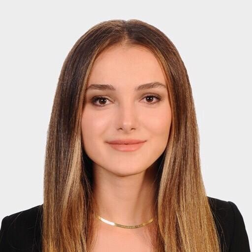

```python
img = cv2.imread('hw2-img.jpeg')
cv2_imshow(img)
```

```python
img.shape
```

```
(512, 512, 3)
```

The first 512 number is the number of rows, that is, the number of vertical pixels, while the second number of 512 is the number of columns, that is, the horizontal pixels. 3 is the channel number. To talk about these channels, as we know, there are 3 primary colors: Red, green, blue and other colors are derivatives of these 3 primary colors.Each pixel value also contains these 3 primary colors and we can see these values by printing any element of the matrix

Now, to split the image into its three channels, we simply need to call the split function from the cv2 module, passing as input our original image.

```python
b,g,r = cv2.split(img)
img = cv2.merge((b,g,r))
b = img[:,:,0]
g = img[:,:,1]
r = img[:,:,2]
```

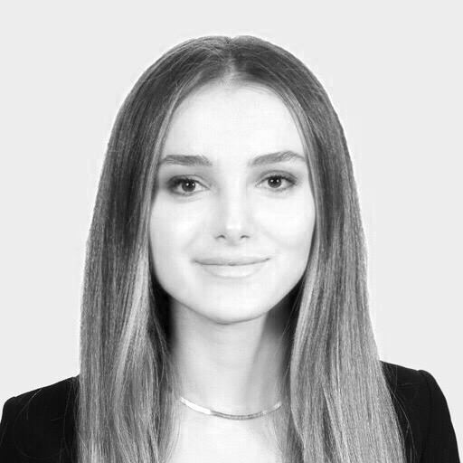

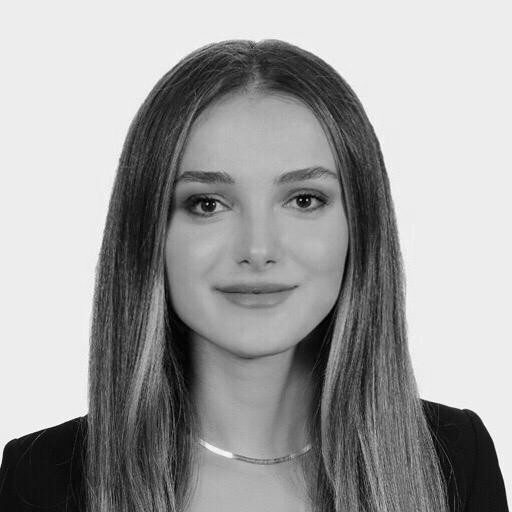

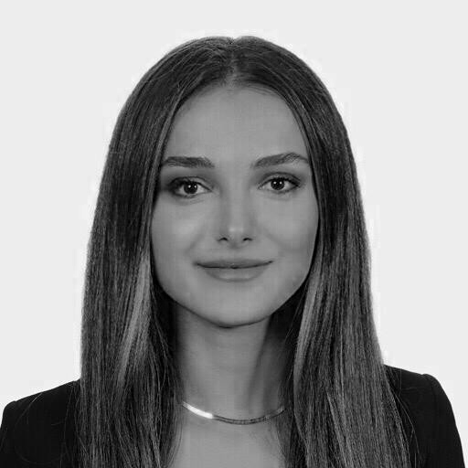

```
-1
```

```python
# show each channel individually
cv2_imshow(r)  # RED

cv2_imshow(g)  #GREEN

cv2_imshow(b)  #BLUE

cv2.waitKey(0)
```

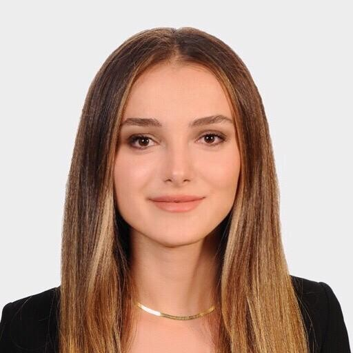

```python
#lets check, merge individual channels into a single color image
img = cv2.merge((B,G,R))
cv2_imshow(img)
```

```python
#For each channel, take the average of the columns and plot the average as a line plot for each
#channel on a single plot
channel_Red = pd.DataFrame(r)
channel_Blue= pd.DataFrame(b)
channel_Green = pd.DataFrame(g)
```

```python
av_column = channel_Red.mean(axis=0)
print (av_column)
```

```
0      218.154297
1      216.490234
2      214.037109
3      211.099609
4      209.703125
          ...
507    233.716797
508    235.878906
509    237.152344
510    237.044922
511    237.201172
Length: 512, dtype: float64
```

```python
av_column = channel_Blue.mean(axis=0)
print (av_column)
```

```
0      218.005859
1      216.341797
2      213.943359
3      211.011719
4      209.726562
          ...
507    233.810547
508    235.972656
509    237.246094
510    237.138672
511    237.294922
Length: 512, dtype: float64
```

```python
av_column = channel_Green.mean(axis=0)
print (av_column)
```

```
0      217.994141
1      216.330078
2      213.849609
3      210.914062
4      209.515625
          ...
507    233.654297
508    235.816406
509    237.089844
510    236.982422
511    237.138672
Length: 512, dtype: float64
```

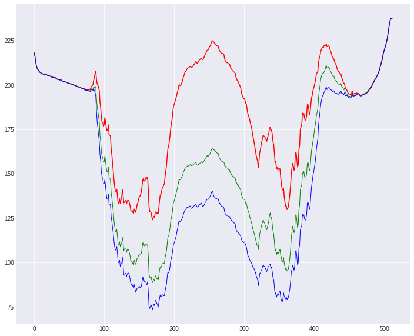

```python
plt.plot(range(0,512),channel_Red.mean(axis=0),color='red')
plt.plot(range(0,512),channel_Green.mean(axis=0), color='green', linewidth=1.0)
plt.plot(range(0,512),channel_Blue.mean(axis=0), color='blue', linewidth=1.0)
```

Subtract one half of the image from the other half (choice of halves is up to us but dividing the head image vertically into two parts make more sense)

```python
# start vertical devide image
height = b.shape[0]
width = b.shape[1]
# Cut the image in half
width_cutoff = width // 2
left1 = b[:, :width_cutoff]
cv2.imwrite("part_left_blue.jpg", left1)
right1 = b[:, width_cutoff:]
cv2.imwrite("part_right_blue.jpg", right1)
# finish vertical devide image
```

```
True
```

```python
#lets check the shape of new image
print(left1.shape)
```

```
(512, 256)
```

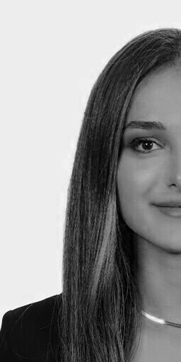

```python
img_left_part_blue = cv2.imread('part_left_blue.jpg')
cv2_imshow(img_left_part_blue)
```

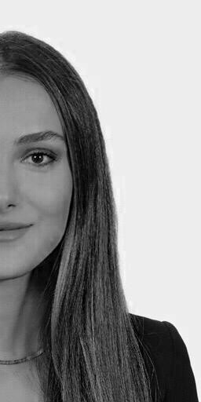

```python
img_right_part_blue = cv2.imread('part_right_blue.jpg')
cv2_imshow(img_right_part_blue)
```

```python
sub = cv2.subtract(img_left_part_blue,img_right_part_blue)
```

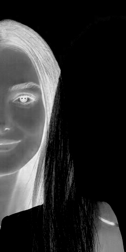

```python
#image after subtraction
cv2_imshow(sub)
```

```python
# start vertical devide image
height = r.shape[0]
width = r.shape[1]
# Cut the image in half
width_cutoff = width // 2
left1 = r[:, :width_cutoff]
cv2.imwrite("part_left_red.jpg", left1)
right1 = r[:, width_cutoff:]
cv2.imwrite("part_right_red.jpg", right1)
# finish vertical devide image
```

```
True
```

```python
#lets check the shape of new image
print(left1.shape)
```

```
(512, 256)
```

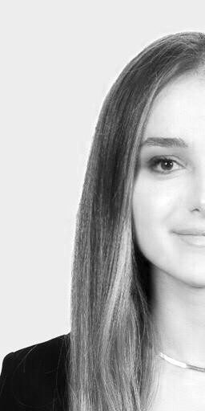

```python
img_left_part_red = cv2.imread('part_left_red.jpg')
cv2_imshow(img_left_part_red)
```

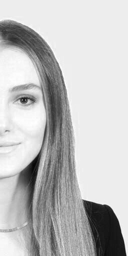

```python
img_right_part_red = cv2.imread('part_right_red.jpg')
cv2_imshow(img_right_part_red)
```

```python
sub = cv2.subtract(img_left_part_red,img_right_part_red)
```

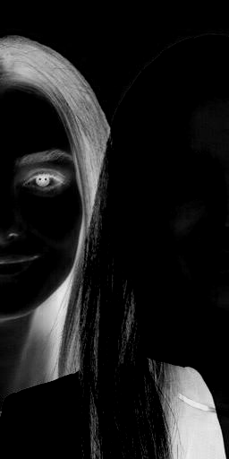

```python
#image after subtraction
cv2_imshow(sub)
```

```python
# start vertical devide image
height = g.shape[0]
width = g.shape[1]
# Cut the image in half
width_cutoff = width // 2
left1 = g[:, :width_cutoff]
cv2.imwrite("part_left_green.jpg", left1)
right1 = g[:, width_cutoff:]
cv2.imwrite("part_right_green.jpg", right1)
# finish vertical devide image
```

```
True
```

```python
#lets check the shape of new image
print(left1.shape)
```

```
(512, 256)
```

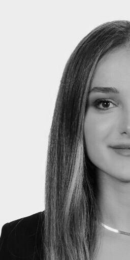

```python
img_left_part_green = cv2.imread('part_left_green.jpg')
cv2_imshow(img_left_part_green)
```

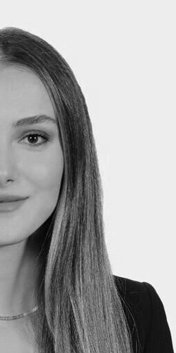

```python
img_right_part_green = cv2.imread('part_right_green.jpg')
cv2_imshow(img_right_part_green)
```

```python
sub = cv2.subtract(img_left_part_green,img_right_part_green)
```

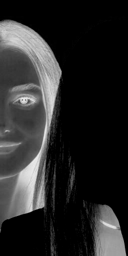

```python
#image after subtraction
cv2_imshow(sub)
```

Noisy Image

```python
noisy_image = img.copy()
```

```python
uniform = np.random.uniform(low=0, high = noisy_image.max()*0.1, size = (512,512))
for i in range(0,3):
    noisy_image[:, :, i] = noisy_image[:,:,i] + uniform.astype(np.int)
```

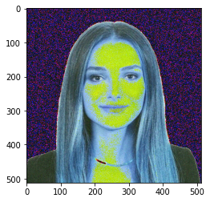

```python
plt.imshow(noisy_image)
```

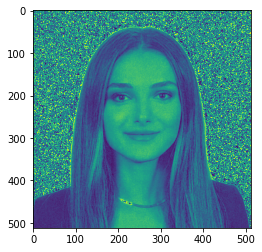

```python
plt.imshow(noisy_image[:,:,0])
```

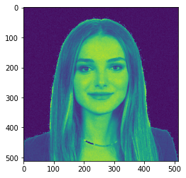

```python
plt.imshow(noisy_image[:,:,1])
```

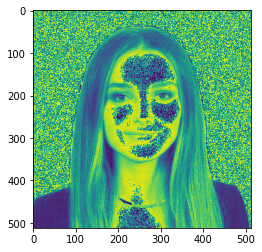

```python
plt.imshow(noisy_image[:,:,2])
```

References

https://www.mygreatlearning.com/blog/opencv-tutorial-in-python/

https://davidegerosa.com/nsphere/

https://mc-stan.org/users/documentation/case-studies/curse-dims-python.html